# Gene profiling analyses

Jenna Crowe-Riddell

28 September 2017

# Background

## RNA read count data

Consists of table of expected counts for each ‘gene id’ (King cobra) and snake sample. Let’s view the first 6 lines of count table:

```r
head(dge)
```

```
##     gene_id HMAJ_testis ATEN_tailA2 ATEN_tailB5 ATEN_body BRH_vno
## 1     gene0         148          82         180       133      23
## 2     gene1          31         156         378       308      33
## 3    gene10           0           0           0         0       0
## 4   gene100         222           3          75         5      11
## 5  gene1000        1091         229        1338       455      48
## 6 gene10000           0           0           0         0       0
##   ALAjuv_tailA2 ALAjuv_tailB5 ALAjuv_body NSC_vno HMAJ_heart ALA_vno
## 1           926           280         583     188        135     376
## 2           136           151          64      63        123      47
## 3             0             0           0       0          0       0
## 4            57            22          28      89          2      74
## 5           464           187         361     404       4355    3132
## 6             0             0           0       0          0       0
##   ALA_tailA2 ALA_eye
## 1         63    1207
## 2         49     443
## 3          0       0
## 4        123      28
## 5       1640    6157
## 6          0       0
```

Can also view our sample information:

```r
names(sampleinfo)
```

```
## [1] "gene_id"    "experiment" "species"    "seqYear"    "tissue"
```

# Clustering data

## MDS plot

The function plotMDS draws a multi-dimensional scaling plot of the RNA samples in which distances correspond to leading log-fold-changes between each pair of RNA samples. The leading log-fold-change is the average (root-mean-square) of the largest absolute log-foldchanges between each pair of samples. This plot can be viewed as a type of unsupervised clustering.

To see how the RNA samples are clustering, we need to transform the count table (of expected read counts) into a data matrix and DGElist object, then normalise using the ‘calcNormFactors()’ function.

```r
dge %<>% column_to_rownames("gene_id") %>%
  as.matrix() %>%
  edgeR::DGEList() %>%
  calcNormFactors()
```

Then plot the MDS using ‘plotMDS’ function and ggplot2 (to overlay sample information and make it look pretty).

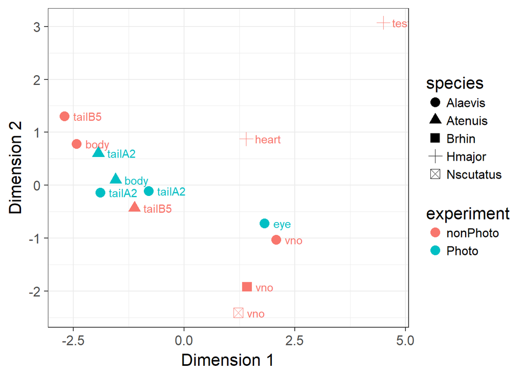